# Medidas Tendencia Central Para Tablas sin Intervalo

Estadística Descriptiva

11/3/2020

## Cálculo de cuartiles para datos agrupados por intervalos

Los cuartiles son los tres valores de la variable que dividen a un conjunto de datos ordenados en cuatro partes iguales.

Cuando nos presentan los datos en una tabla de frecuencias, el proceso de encontrar cada uno de los cuartiles es el siguiente:

Buscamos la categoría o **intervalo** donde se encuentra el siguiente valor $\frac{k \cdot N}{4}$ donde $k$ representa el cuartil que deseamos hallar, o sea $k = 1, 2, 3$, en la columna de **frecuencias absolutas acumuladas**.

Una vez ya tenemos el intervalo dado, aplicamos la siguiente fórmula para encontrar el cuartil deseado:

$$Q_k = L_i + \frac{\frac{k \cdot N}{4} - F_{i-1}}{f_i} \cdot A_i$$

Donde tenemos que:

- $k = 1, 2, 3$, el cuartil que queremos encontrar.
- $L_i$ es el límite inferior de la clase donde se encuentra el cuartil.
- $N$ es el número de datos que tenemos o la suma de las frecuencias absolutas.
- $F_{i-1}$ es la **frecuencia acumulada** anterior al intervalo donde se encuentra el cuartil.
- $A_i$ es la amplitud del intervalo.

**Ejemplo:**

A partir de la siguiente tabla de frecuencia, calcule el tercer cuartil.

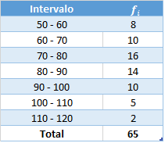

En primer lugar crearemos una nueva columna con los valores de la frecuencia acumulada:

En la primera casilla colocamos la primera frecuencia absoluta.

En la segunda casilla sumamos el valor de la frecuencia acumulada anterior más la frecuencia absoluta correspondiente y así sucesivamente hasta la última, que tiene que ser igual a $N = 65$.

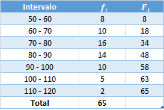

Ahora procederemos a encontrar el tercer cuartil con los datos que tenemos en la tabla. Comenzamos por buscar el intervalo donde se encuentra el tercer cuartil, multiplicando $3$ por $N=65$ y dividiendo por $4$.

$$\frac{3 \times 65}{4} = 48.75$$

Aplicaremos la fórmula para el cálculo de cuartiles para datos agrupados, teniendo en cuenta los siguiente datos:

$$\begin{align}
L_i &= 90 \\
F_{i-1} &= 48 \\
f_i &= 10 \\
A_i &= 10
\end{align}$$

El resultado de la fórmula sería el siguiente:

$$Q_3 = L_i + \frac{\frac{k \cdot N}{4} - F_{i-1}}{f_i} \times A_i = 90 + \frac{48.75 - 48}{10} \times 10 = 90.75$$

Entonces el tercer cuartil a partir de la tabla de frecuencia anterior es $90.75$, lo que indica que el $75\%$ de los datos son inferiores a $90.75$ y solo el $25\%$ de los datos son superiores a ese número.

## Media, mediana y moda para tablas sin intervalos

A veces nos dan tablas de frecuencia, pero los grupos no pertenecen a intervalos, sino que se tratan de números puntuales.

La **media** es el valor que se obtiene al sumar todos los datos multiplicados por su frecuencia y dividir el resultado entre la cantidad de datos. La **mediana** es el valor que ocupa la posición central si $n$ es impar, y es el promedio de los dos datos centrales si $n$ es par, cuando todos los datos están ordenados. La **moda** es valor con mayor frecuencia absoluta. Cuando buscamos encontrar la media, mediana y moda para datos agrupados sin intervalos o agrupados puntualmente, necesitamos realizar algunos pasos adicionales y conocer un par de fórmulas. Veamos como hacerlo.

### Media

La **media** es el valor que se obtiene al sumar todos los datos multiplicados por su frecuencia y dividir el resultado entre la cantidad de datos. Usamos la siguiente fórmula:

$$\bar{x} = \frac{x_1 \cdot f_1 + x_2 \cdot f_2 + \cdots x_n \cdot f_n}{N} = \frac{\sum_{i=1}^N x_i \cdot f_i}{N}$$

**Ejemplo:**

Calcular la media a partir de la siguiente tabla de frecuencia:

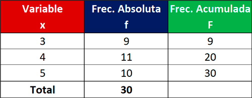

Para calcula la media, vamos a agregar una columna adicional, en la que multiplicaremos el valor de la variable ($x$) por la frecuencia absoluta ($f$).

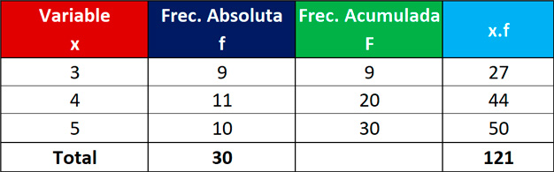

Y ahora, aplicando la fórmula anterior, obtenemos:

$$\bar{x} = \frac{x_1 \cdot f_1 + x_2 \cdot f_2 + x_3 \cdot f_3}{N} = \frac{121}{30} = 4.033$$

### Mediana

La **mediana** es el valor que ocupa la posición central si $n$ es impar, y es el promedio de los dos datos centrales si $n$ es par, cuando todos los datos están ordenados.

Una manera rápida de enconrar la mediana, debemos comenzar el dato que está en el punto central de acuerdo a la siguiente fórmula:

$$\textrm{posición} = \frac{N+1}{2}$$

Y luego ubicamos el valor de esa posición en la columna de las frecuencias acumuladas de la tabla de frecuencias.

**Ejemplo (con $N$ impar)**

Calcular la mediana de la siguiente tabla de frecuencia:

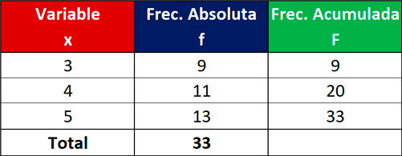

Encontramos la posición del valor que está ubicado al centro:

$$\textrm{posición} = \frac{N+1}{2} = \frac{33+1}{2} = \frac{34}{2} = 17$$

Ahora buscamos la posición $17$ en la columna de las **frecuencias acumuladas**:

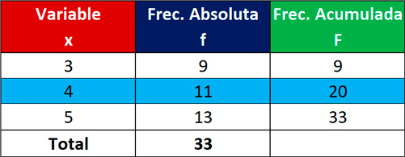

El valor de la variable $x$ que ocupa dicha posición es $4$, por lo tanto la mediana $M_e = 4$.

**Ejemplo ($N$ par)**

Calcular la mediana de la siguiente tabla de frecuencia:

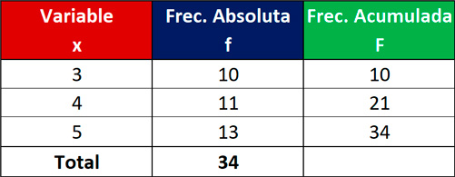

Comenzamos por encontrar la posición del valor que se encuentra en el centro de la distribución:

$$\textrm{posición} = \frac{N+1}{2} = \frac{34+1}{2} = \frac{35}{2} = 17.5$$

Como hemos obtenido un valor con decimales, significa que la mediana será el promedio del valor que ocupa la posición $17$ con el valor que ocupa la posición $18$.

Buscamos los valores de las posiciones $17$ y $18$ en la columna de las frecuencias absolutas acumuladas:

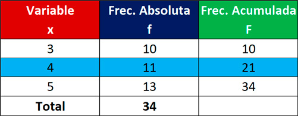

La posición $17$ pertenece al valor $x = 4$, y la posición $18$ también pertenece al mismo valor. Por lo tanto:

$$M_e = \frac{4+4}{2} = 4$$

### Moda

La moda es el valor con mayor frecuencia absoluta.

**Ejemplo:**

Calcular la moda de la siguiente tabla de frecuencia:

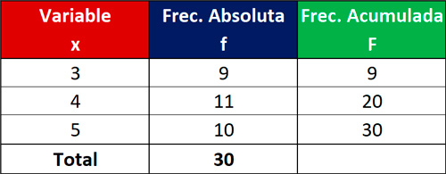

La moda es el valor con mayor frecuencia absoluta, así que ubicamos el mayor valor de frecuencia absoluta con su correspondiente valor de la variable x:

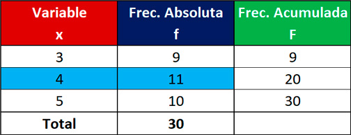

El valor con mayor frecuencia absoluta es el $4$, por lo tanto la moda $M_o = 4$.